# Modelo individual estocástico em tempos discretos adaptado ao município do Rio de Janeiro

**Objetivos:**

## Montando um cenário reduzido do Rio de Janeiro

```python
tx_reducao = 1000
cenario_rio = episiming.cenarios.RiodeJaneiro(tx_reducao)
print(f'População do cenário reduzido: {cenario_rio.num_pop}\n')
```

```
População do cenário reduzido: 6333
```

## Simulações

### Dados temporais para as simulações

```python
dt = 1 # passo de tempo
t_0 = 0 # instante initial
num_dt = 80 # número de passos
dados_temporais = [t_0, dt, num_dt] # instantes de tempo
```

### Parâmetros de base

```python
num_infectados_0_base = 20 # número inicial de infectados
beta_r_base = 0.5 # taxa de contágio nas residências
beta_esc_base = 0.4 # taxa de contágio nas escolas
beta_emp_base = 0.2 # taxa de contágio no trabalho
beta_c_base = 0.2 # taxa de contágio na comunidade
gamma_base = 0.1 # inverso do tempo de recuperação
```

### Simulação com os parâmetros de base

```python
num_infectados_0 = num_infectados_0_base
beta_r = beta_r_base
beta_esc = beta_esc_base
beta_emp = beta_emp_base
beta_c = beta_c_base
gamma = gamma_base

cenario_rio.inicializa_infeccao(num_infectados_0, beta_r, beta_esc, beta_emp, beta_c,
                                gamma)
```

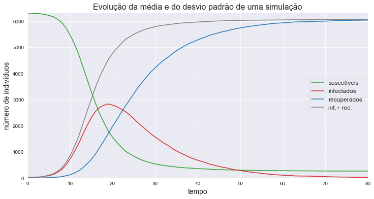

```
CPU times: user 21.1 s, sys: 648 ms, total: 21.8 s
Wall time: 31.7 s
```

```python
%%time
num_sim = 1 # número de simulações
X = cenario_rio.evolui_jit(dados_temporais, num_sim, show='sd')
G=cenario_rio.redes

with open(os.path.join('..', 'input','modelos_individuais','pickle-example.p'), 'wb') as pfile:
    pickle.dump(G, pfile)
```

- Ver GEMFpy nos artigos
  - Sahneh, Faryad Darabi, Caterina Scoglio, and Piet Van Mieghem. "Generalized epidemic mean-field model for spreading processes over multilayer complex networks." IEEE/ACM Transactions on Networking 21.5 (2013): 1609-1620.
  - Sahneh, Faryad Darabi, et al. "GEMFsim: A stochastic simulator for the generalized epidemic modeling framework." Journal of computational science 22 (2017): 36-44.
  - Youssef, Mina, and Caterina Scoglio. "An individual-based approach to SIR epidemics in contact networks." Journal of theoretical biology 283.1 (2011): 136-144.

```python
%%time

N = G[0].number_of_nodes()

case=1
#rede de individuos
#este numero define o numero de contato de cada no da rede
pnodes=0.0045155

FG = nx.erdos_renyi_graph(N, pnodes,52,True)
```

```
CPU times: user 8.7 s, sys: 142 ms, total: 8.84 s
Wall time: 9.55 s
```

### Construção da rede

Pegamos uma rede aleatória para indivíduos e Cenário Rio para o resto das redes: residências, escolas e empressas.

```python
%%time

#Estas sao as redes de residenca, escolas e empresas
#se trasnforman en redes tipo direta para combinar com as rede de indiviuos
H1 = G[0].to_directed()
H2 = G[1].to_directed()
H3 = G[2].to_directed()
```

```
CPU times: user 6.33 s, sys: 223 ms, total: 6.55 s
Wall time: 7.07 s
```

```python
%%time

#Combina todas as redes
NetSet1=GEMFPy.MyNet(FG, weight='weight')
NetSet3=GEMFPy.MyNet(H2, weight='weight')
NetSet2=GEMFPy.MyNet(H1, weight='weight')
NetSet4=GEMFPy.MyNet(H3, weight='weight')

#mais de uma Net

NetSet=[NetSet1,NetSet2,NetSet3,NetSet4]

Net= GEMFPy.NetCmbn(NetSet)
```

```
CPU times: user 13.9 s, sys: 255 ms, total: 14.2 s
Wall time: 15.1 s
```

### Simulaçoes para o modelo SEIR

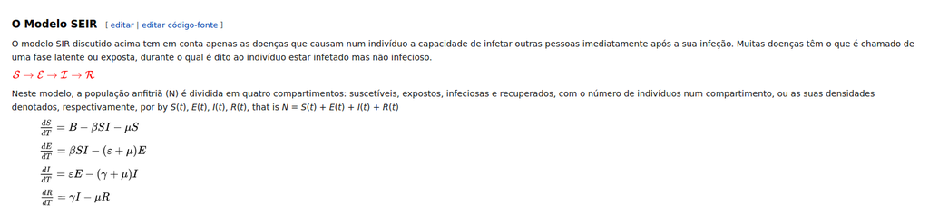

```python
Image(filename=os.path.join('..','input', 'compartimentais', 'SEIR1.png'), width=2800)
```

### Definição dos parâmetros e posição inicial dos indivíduos infectados

- Os numeros pnodes e beta vao definir a potencia de propagacao da epidemia

```python
#parametros
beta_ind=0.01

delta = gamma_base; Lambda=0.26

beta=[beta_ind,beta_r_base,beta_esc_base,beta_emp_base]

Para = GEMFPy.Para_SEIR(delta, beta, Lambda)

x0 = np.zeros(N)
x0 = GEMFPy.Initial_Cond_Gen(N, Para[1][0], 20, x0)
```

### Simulação parra os dados acima

```
CPU times: user 31.8 s, sys: 534 ms, total: 32.3 s
Wall time: 39 s
```

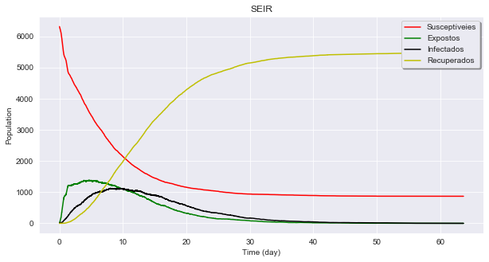

```python
%%time
StopCond = ['RunTime', 80]

ts, n_index, i_index, j_index = GEMFPy.GEMF_SIM(Para, Net, x0, StopCond,N)

M = Para[0]
T, StateCount = GEMFPy.Post_Population(x0, M, N, ts, i_index, j_index)

fig = plt.figure(figsize=(10,5))
# for i in range(M):
# plt.plot(T, StateCount[0,:]/N,'r',label='Susceptible')
plt.plot(T, StateCount[0,:],'r',label='Susceptíveies')
plt.plot(T, StateCount[1,:],'g',label='Expostos')
plt.plot(T, StateCount[2,:],'k',label='Infectados')
plt.plot(T, StateCount[3,:],'y',label='Recuperados')

plt.xlabel('Time (day)')
plt.ylabel('Population')
plt.title('SEIR')
legend = plt.legend(loc='upper right', shadow=True)

output1 = "Case"+str(int(case)) + "beta"+str(float(beta_ind))+"proba"+ str(float(pnodes))

plt.savefig(os.path.join('..', 'input','modelos_individuais', "Simulacao" +output1+ ".png"))
```

### Agora, aplica-se o método de montecarlo para avaliar uma posição relativa de indivíduos infetados

- Se mostra que é tão importante uma posição inicial, também o semente Gerador do número aleatório

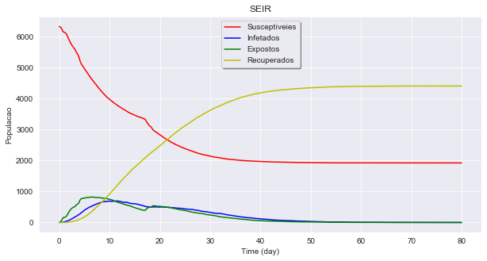

```
CPU times: user 5min 47s, sys: 5.29 s, total: 5min 52s
Wall time: 6min 18s
```

```python
%%time

Montecarlo=1

if Montecarlo==1:

    #numero de simulacoes em MonteCarlo
    nsim=5

    t, f = GEMFPy.MonteCarlo(Net, Para,  StopCond, 1, 4, .1, nsim, N, x_init = np.zeros(N) )

    fig2 = plt.figure(figsize=(10,5))
    # for i in range(M):
    # plt.plot(T, StateCount[0,:]/N,'r',label='Susceptible')
    plt.plot(t,N*f[0,:],'r',label='Susceptíveies')
    plt.plot(t,N*f[2,:],'b',label='Infetados')
    plt.plot(t,N*f[1,:],'g',label='Expostos')
    plt.plot(t,N*f[3,:],'y',label='Recuperados')

    plt.xlabel('Time (day)')
    plt.ylabel('Populacao')
    plt.title('SEIR')
    legend = plt.legend(loc='upper center', shadow=True)
    plt.savefig(os.path.join('..', 'input','modelos_individuais', 'Montecarlo' +output1+ '.png'))
    plt.show()
```

```python
print(output1)
```

```
Case1beta0.01proba0.0045155
```

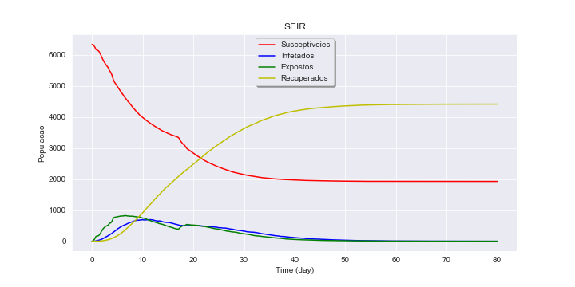

```python
Image(filename=os.path.join('..', 'input','modelos_individuais', 'MontecarloCase1beta0.01proba0.0045155.png'), width=2800)
```